# Self-Driving Car Engineer Nanodegree

## Project: Build a Traffic Sign Recognition Classifier

In this notebook, a template is provided for you to implement your functionality in stages which is required to successfully complete this project. If additional code is required that cannot be included in the notebook, be sure that the Python code is successfully imported and included in your submission, if necessary. Sections that begin with **'Implementation'** in the header indicate where you should begin your implementation for your project. Note that some sections of implementation are optional, and will be marked with **'Optional'** in the header.

In addition to implementing code, there will be questions that you must answer which relate to the project and your implementation. Each section where you will answer a question is preceded by a **'Question'** header. Carefully read each question and provide thorough answers in the following text boxes that begin with **'Answer:'**. Your project submission will be evaluated based on your answers to each of the questions and the implementation you provide.

> **Note:** Code and Markdown cells can be executed using the **Shift + Enter** keyboard shortcut. In addition, Markdown cells can be edited by typically double-clicking the cell to enter edit mode.

## Step 0: Load The Data

```python
# Load pickled data
import pickle

# TODO: Fill this in based on where you saved the training and testing data

training_file = './traffic-signs-data/train.p'
testing_file = './traffic-signs-data/test.p'

with open(training_file, mode='rb') as f:
    train = pickle.load(f)
with open(testing_file, mode='rb') as f:
    test = pickle.load(f)

FEATURES = 'features'
LABELS = 'labels'
SIZES = 'sizes'
COORDS = 'coords'

X_train_raw, y_train_raw, Sizes_train, Coords_train = train[FEATURES], train[LABELS], train[SIZES], train[COORDS]
X_test, y_test, Sizes_test, Coords_test = test[FEATURES], test[LABELS], train[SIZES], train[COORDS]

print(X_train_raw.shape,y_train_raw.shape,X_test.shape,y_test.shape)
print(Sizes_train.shape,Sizes_test.shape,Coords_train.shape,Coords_test.shape)
```

```
(39209, 32, 32, 3) (39209,) (12630, 32, 32, 3) (12630,)
(39209, 2) (39209, 2) (39209, 4) (39209, 4)
```

## Step 1: Dataset Summary & Exploration

Complete the basic data summary below.

```python
### Replace each question mark with the appropriate value.

# TODO: Number of training examples
n_train_raw = X_train_raw.shape[0]

# TODO: Number of testing examples.
n_test = X_test.shape[0]

# TODO: What's the shape of an traffic sign image?
image_shape = X_test.shape

# TODO: How many unique classes/labels there are in the dataset.
n_classes = 43

print("Number of training examples =", n_train_raw)
print("Number of testing examples =", n_test)
print("Image data shape =", image_shape)
print("Number of classes =", n_classes)
```

```
Number of training examples = 39209
Number of testing examples = 12630
Image data shape = (12630, 32, 32, 3)
Number of classes = 43
```

```python
#jitter generating function implemented  by Vivek Yadav
import cv2
def transform_image(img,ang_range,shear_range,trans_range):
    '''
    This function transforms images to generate new images.
    The function takes in following arguments,
    1- Image
    2- ang_range: Range of angles for rotation
    3- shear_range: Range of values to apply affine transform to
    4- trans_range: Range of values to apply translations over.

    A Random uniform distribution is used to generate different parameters for transformation

    '''
    # Rotationsave_file
    #print(img.shape)

    ang_rot = np.random.uniform(ang_range)-ang_range/2
    rows,cols,ch = img.shape
    Rot_M = cv2.getRotationMatrix2D((cols/2,rows/2),ang_rot,1)

    # Translation
    tr_x = trans_range*np.random.uniform()-trans_range/2
    tr_y = trans_range*np.random.uniform()-trans_range/2
    Trans_M = np.float32([[1,0,tr_x],[0,1,tr_y]])

    # Shear
    pts1 = np.float32([[5,5],[20,5],[5,20]])

    pt1 = 5+shear_range*np.random.uniform()-shear_range/2
    pt2 = 20+shear_range*np.random.uniform()-shear_range/2

    pts2 = np.float32([[pt1,5],[pt2,pt1],[5,pt2]])

    shear_M = cv2.getAffineTransform(pts1,pts2)

    img = cv2.warpAffine(img,Rot_M,(cols,rows))
    img = cv2.warpAffine(img,Trans_M,(cols,rows))
    img = cv2.warpAffine(img,shear_M,(cols,rows))
    #print(img.shape)
    return img
```

Visualize the German Traffic Signs Dataset using the pickled file(s). This is open ended, suggestions include: plotting traffic sign images, plotting the count of each sign, etc.

The [Matplotlib](http://matplotlib.org/) [examples](http://matplotlib.org/examples/index.html) and [gallery](http://matplotlib.org/gallery.html) pages are a great resource for doing visualizations in Python.

**NOTE:** It's recommended you start with something simple first. If you wish to do more, come back to it after you've completed the rest of the sections.

My tried actions;first,get a view of random image ,then,view different label image of the same class id of the traffic sign.

```
the corresponding label/class id of the traffic sign is  3
```

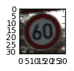

```python
### Data exploration visualization goes here.
### Feel free to use as many code cells as needed.
import random
import matplotlib.pyplot as plt
# Visualizations will be shown in the notebook.
%matplotlib inline

#labelID=33
#while 1:
index = random.randint(0, len(X_train_raw))
#    if y_train[index]==labelID:break

image = X_train_raw[index].squeeze()


plt.figure(figsize=(1,1))
plt.imshow(image)
#plt.imshow(image, cmap="gray")
print("the corresponding label/class id of the traffic sign is ",y_train_raw[index])
```

## Step 2: Design and Test a Model Architecture

Design and implement a deep learning model that learns to recognize traffic signs. Train and test your model on the [German Traffic Sign Dataset](http://benchmark.ini.rub.de/?section=gtsrb&subsection=dataset).

There are various aspects to consider when thinking about this problem:

- Neural network architecture
- Play around preprocessing techniques (normalization, rgb to grayscale, etc)
- Number of examples per label (some have more than others).
- Generate fake data.

Here is an example of a [published baseline model on this problem](http://yann.lecun.com/exdb/publis/pdf/sermanet-ijcnn-11.pdf). It's not required to be familiar with the approach used in the paper but, it's good practice to try to read papers like these.

**NOTE:** The LeNet-5 implementation shown in the classroom at the end of the CNN lesson is a solid starting point. You'll have to change the number of classes and possibly the preprocessing, but aside from that it's plug and play!

### Implementation

Use the code cell (or multiple code cells, if necessary) to implement the first step of your project. Once you have completed your implementation and are satisfied with the results, be sure to thoroughly answer the questions that follow.

```python
# see how many input data for each class id of traffic sign
import numpy as np
import random
num_classID=np.zeros(n_classes)

for i in range(len(y_train_raw)):
    num_classID[y_train_raw[i]]+=1
n_label_max=np.max(num_classID)
print(num_classID)
print(n_label_max)
```

```
[  210.  2220.  2250.  1410.  1980.  1860.   420.  1440.  1410.  1470.
  2010.  1320.  2100.  2160.   780.   630.   420.  1110.  1200.   210.
   360.   330.   390.   510.   270.  1500.   600.   240.   540.   270.
   450.   780.   240.   689.   420.  1200.   390.   210.  2070.   300.
   360.   240.   240.]
2250.0
```

```python
#split training dato into training and validation set
from sklearn.utils import shuffle
ration_validation=0.3
X_train_raw,y_train_raw = shuffle(X_train_raw, y_train_raw)

n_validation=int(ration_validation*n_train_raw)
n_train=n_train_raw-n_validation

X_train_unjittered= X_train_raw[:n_train]
y_train_unjittered= y_train_raw[:n_train]
X_validation_unjittered = X_train_raw[n_train:]
y_validation_unjittered = y_train_raw[n_train:]
print(n_train,n_validation)
print(X_train_unjittered.shape,y_train_unjittered.shape,X_validation_unjittered.shape,y_validation_unjittered.shape)

num_train_classID=np.zeros(n_classes)
num_validation_classID=np.zeros(n_classes)

for i in range(n_train):
    num_train_classID[y_train_unjittered[i]]+=1
n_train_label_max=np.max(num_train_classID)
print(num_train_classID)
print("the maximum number of a label in training set is ",n_train_label_max)

for i in range(n_validation):
    num_validation_classID[y_validation_unjittered[i]]+=1
n_validation_label_max=np.max(num_validation_classID)
print(num_validation_classID)
print("the maximum number of a label in validation set is ",n_validation_label_max)
```

```
27447 11762
(27447, 32, 32, 3) (27447,) (11762, 32, 32, 3) (11762,)
[  143.  1544.  1575.   994.  1421.  1295.   277.   978.   998.  1028.
  1412.   930.  1480.  1544.   537.   440.   301.   822.   830.   155.
   254.   216.   263.   364.   182.  1058.   407.   164.   350.   184.
   323.   555.   166.   469.   292.   820.   287.   145.  1435.   210.
   265.   167.   167.]
the maximum number of a label in training set is  1575.0
[  67.  676.  675.  416.  559.  565.  143.  462.  412.  442.  598.  390.
  620.  616.  243.  190.  119.  288.  370.   55.  106.  114.  127.  146.
   88.  442.  193.   76.  190.   86.  127.  225.   74.  220.  128.  380.
  103.   65.  635.   90.   95.   73.   73.]
the maximum number of a label in validation set is  676.0
```

```python
# generate jitter data ,making data balanceed
X_train=[]
y_train=[]
X_validation=[]
y_validation=[]
n_times=1
print("n_train" ,n_train)
for m in range(n_times):
    for i in range(n_train):
         for j in range(n_classes):
            if y_train_unjittered[i]==j:
                for k in range(int(round(n_train_label_max/num_train_classID[j]))):
                    img = transform_image(X_train_unjittered[i],10,5,5)
                    X_train.append(img)
                    y_train.append(y_train_unjittered[i])
print("the jitter trainning data size is",len(X_train))
for i in range(n_train):
    X_train.append(X_train_unjittered[i])
    y_train.append(y_train_unjittered[i])

X_train=np.array(X_train)
y_train=np.array(y_train)
n_train=len(X_train)
print("the shape of final X_train ,y_train is",X_train.shape,y_train.shape)


for m in range(n_times):
    for i in range(n_validation):
        for j in range(n_classes):
            if y_validation_unjittered[i]==j:
                for k in range(int(round(n_validation_label_max/num_validation_classID[j]))):
                    img = transform_image(X_validation_unjittered[i],10,5,5)
                    X_validation.append(img)
                    y_validation.append(y_validation_unjittered[i])

print("the jitter trainning data size is",len(X_validation))
for i in range(n_validation):
    X_validation.append(X_validation_unjittered[i])
    y_validation.append(y_validation_unjittered[i])

X_validation=np.array(X_validation)
y_validation=np.array(y_validation)
n_validation=len(X_validation)


print("the shape of final X_validation ,y_validation is",X_validation.shape,y_validation.shape)

X_train,y_train = shuffle(X_train, y_train)
X_validation,y_validation = shuffle(X_validation, y_validation)

"""
n_validation=n_train_raw

X_validation=X_train_raw
y_validation=y_train_raw

X_train=[]
y_train=[]
#for k in range(4):
for i in range(len(y_train_raw)):
    for j in range(n_classes):
        if y_train_raw[i]==j:
            for k in range(int(round(n_label_max/num_classID[j]))):
                img = transform_image(image,10,5,2)
                X_train.append(img)
                y_train.append(y_train_raw[i])
X_train=np.array(X_train)
y_train=np.array(y_train)
n_train=len(X_train)

print("the shape of X_train y_train is",X_train.shape,y_train.shape)


"""


"""
image =imread()
plt.imshow(image);
plt.axis('off');
plt.show()
gs1 = gridspec.GridSpec(10, 10)
gs1.update(wspace=0.01, hspace=0.02) # set the spacing between axes.
plt.figure(figsize=(12,12))
for i in range(100):
    ax1 = plt.subplot(gs1[i])
    ax1.set_xticklabels([])
    ax1.set_yticklabels([])
    ax1.set_aspect('equal')
    img = transform_image(image,20,10,5)

    plt.subplot(10,10,i+1)
    plt.imshow(img)
    plt.axis('off')

plt.show()
"""
```

```
n_train 27447
the jitter trainning data size is 68204
the shape of final X_train ,y_train is (95651, 32, 32, 3) (95651,)
the jitter trainning data size is 29573
the shape of final X_validation ,y_validation is (41335, 32, 32, 3) (41335,)
```

[output not shown]

```python
#preprocessing the input data  :RGB to YUV  Gray Y = R*0.299 + G*0.587 + B*0.114
def rgb2gray(rgb):
    return np.dot(rgb[...,:3], [0.299, 0.587, 0.114])

#X_train_gray=np.array([n_train,32,32,1])
#X_test_gray=np.array([n_test,32,32,1])

X_train_gray=np.array(rgb2gray(X_train),dtype=np.float32).reshape((n_train,32,32,1))
X_test_gray=np.array(rgb2gray(X_test),dtype=np.float32).reshape((n_test,32,32,1))
X_validation_gray=np.array(rgb2gray(X_validation),dtype=np.float32).reshape((n_validation,32,32,1))

print("the shape of X_train_gray is ",X_train_gray.shape)
print("the shape of X_validation_gray is ",X_validation_gray.shape)
print("the shape of X_test_gray is ",X_test_gray.shape)


#print("y_test",y_test)
```

```
the shape of X_train_gray is  (95651, 32, 32, 1)
the shape of X_validation_gray is  (41335, 32, 32, 1)
the shape of X_test_gray is  (12630, 32, 32, 1)
```

```python
#data normalizing
import tensorflow as tf

def image_normalizing(data):
    d=np.array(data)
    shape=d.shape
    d=d.reshape(d.size)
    for i in range(d.size):
        d[i]=np.float32((d[i]-128)/128)
    return d.reshape(shape)

X_train_gray_normal=image_normalizing(X_train_gray)
X_test_gray_normal=image_normalizing(X_test_gray)
X_validation_gray_normal=image_normalizing(X_validation_gray)

print("the shape of X_train_gray_normal is ",X_train_gray_normal.shape)
print("the shape of X_validation_gray_normal is ",X_validation_gray_normal.shape)
print("the shape of X_test_gray_normal is ",X_test_gray_normal.shape)


#print("X_train_gray_normal",X_train_gray_normal)
#print("one_hot_y_test",one_hot_y_test)
```

```
the shape of X_train_gray_normal is  (95651, 32, 32, 1)
the shape of X_validation_gray_normal is  (41335, 32, 32, 1)
the shape of X_test_gray_normal is  (12630, 32, 32, 1)
```

```python
# using the leNet structure fist


from tensorflow.contrib.layers import flatten
#shuffling the data pair
X_train_gray_normal,y_train = shuffle(X_train_gray_normal, y_train)

EPOCHS = 20
BATCH_SIZE = 128
#dropout_rate = 0.750

def LeNet(x):
    # Hyperparameters
    mu = 0
    sigma = 0.1

    # SOLUTION: Layer 1: Convolutional. Input = 32x32x1. Output = 28x28x6.
    conv1_W = tf.Variable(tf.truncated_normal(shape=(5, 5, 1, 6), mean = mu, stddev = sigma))
    conv1_b = tf.Variable(tf.zeros(6))
    conv1   = tf.nn.conv2d(x, conv1_W, strides=[1, 1, 1, 1], padding='VALID') + conv1_b

    # SOLUTION: Activation.
    conv1 = tf.nn.relu(conv1)

    # SOLUTION: Pooling. Input = 28x28x6. Output = 14x14x6.
    conv1 = tf.nn.max_pool(conv1, ksize=[1, 2, 2, 1], strides=[1, 2, 2, 1], padding='VALID')

    # SOLUTION: Layer 2: Convolutional. Output = 10x10x16.
    conv2_W = tf.Variable(tf.truncated_normal(shape=(5, 5, 6, 16), mean = mu, stddev = sigma))
    conv2_b = tf.Variable(tf.zeros(16))
    conv2   = tf.nn.conv2d(conv1, conv2_W, strides=[1, 1, 1, 1], padding='VALID') + conv2_b

    # SOLUTION: Activation.
    conv2 = tf.nn.relu(conv2)

    # SOLUTION: Pooling. Input = 10x10x16. Output = 5x5x16.
    conv2 = tf.nn.max_pool(conv2, ksize=[1, 2, 2, 1], strides=[1, 2, 2, 1], padding='VALID')

    # SOLUTION: Flatten. Input = 5x5x16. Output = 400.
    fc0   = flatten(conv2)

    # SOLUTION: Layer 3: Fully Connected. Input = 400. Output = 120.
    fc1_W = tf.Variable(tf.truncated_normal(shape=(400, 120), mean = mu, stddev = sigma))
    fc1_b = tf.Variable(tf.zeros(120))
    fc1   = tf.matmul(fc0, fc1_W) + fc1_b

    # SOLUTION: Activation.
    fc1    = tf.nn.relu(fc1)

    # SOLUTION: Layer 4: Fully Connected. Input = 120. Output = 84.
    fc2_W  = tf.Variable(tf.truncated_normal(shape=(120, 84), mean = mu, stddev = sigma))
    fc2_b  = tf.Variable(tf.zeros(84))
    fc2    = tf.matmul(fc1, fc2_W) + fc2_b

    # SOLUTION: Activation.
    fc2    = tf.nn.relu(fc2)

    # SOLUTION: Layer 5: Fully Connected. Input = 84. Output =  n_classes,in this case equals 43
    fc3_W  = tf.Variable(tf.truncated_normal(shape=(84,  n_classes), mean = mu, stddev = sigma))
    fc3_b  = tf.Variable(tf.zeros( n_classes))
    logits = tf.matmul(fc2, fc3_W) + fc3_b

    return logits


def LeNetModify1(x):
    # Hyperparameters
    mu = 0
    sigma = 0.1

    # SOLUTION: Layer 1: Convolutional. Input = 32x32x1. Output = 28x28x16.
    conv1_W = tf.Variable(tf.truncated_normal(shape=(5, 5, 1, 16), mean = mu, stddev = sigma))
    conv1_b = tf.Variable(tf.zeros(16))
    conv1   = tf.nn.conv2d(x, conv1_W, strides=[1, 1, 1, 1], padding='VALID') + conv1_b

    # SOLUTION: Activation.
    conv1 = tf.nn.relu(conv1)

    # SOLUTION: Pooling. Input = 28x28x16. Output = 14x14x16.
    conv1 = tf.nn.max_pool(conv1, ksize=[1, 2, 2, 1], strides=[1, 2, 2, 1], padding='VALID')

    # SOLUTION: Layer 2: Convolutional. Output = 10x10x32.
    conv2_W = tf.Variable(tf.truncated_normal(shape=(5, 5, 16, 32), mean = mu, stddev = sigma))
    conv2_b = tf.Variable(tf.zeros(32))
    conv2   = tf.nn.conv2d(conv1, conv2_W, strides=[1, 1, 1, 1], padding='VALID') + conv2_b

    # SOLUTION: Activation.
    conv2 = tf.nn.relu(conv2)

    # SOLUTION: Pooling. Input = 10x10x32. Output = 5x5x32.
    conv2 = tf.nn.max_pool(conv2, ksize=[1, 2, 2, 1], strides=[1, 2, 2, 1], padding='VALID')

    # SOLUTION: Flatten. Input = 5x5x32. Output = 800.
    fc0   = flatten(conv2)

    # SOLUTION: Layer 3: Fully Connected. Input = 800. Output = 256.
    fc1_W = tf.Variable(tf.truncated_normal(shape=(800, 256), mean = mu, stddev = sigma))
    fc1_b = tf.Variable(tf.zeros(256))
    fc1   = tf.matmul(fc0, fc1_W) + fc1_b

    # SOLUTION: Activation.
    fc1    = tf.nn.relu(fc1)

    # SOLUTION: Layer 4: Fully Connected. Input = 256. Output = 128.
    fc2_W  = tf.Variable(tf.truncated_normal(shape=(256, 128), mean = mu, stddev = sigma))
    fc2_b  = tf.Variable(tf.zeros(128))
    fc2    = tf.matmul(fc1, fc2_W) + fc2_b

    # SOLUTION: Activation.
    fc2    = tf.nn.relu(fc2)

    # SOLUTION: Layer 5: Fully Connected. Input = 128. Output =  n_classes,in this case equals 43
    fc3_W  = tf.Variable(tf.truncated_normal(shape=(128,  n_classes), mean = mu, stddev = sigma))
    fc3_b  = tf.Variable(tf.zeros( n_classes))
    logits = tf.matmul(fc2, fc3_W) + fc3_b

    return logits
```

```python
# training pipeline

x = tf.placeholder(tf.float32, (None, 32, 32,1))
y = tf.placeholder(tf.int32, (None))
one_hot_y = tf.one_hot(y, n_classes)

rate = 0.001
#logits=LeNet(x)
logits = LeNetModify1(x)
cross_entropy = tf.nn.softmax_cross_entropy_with_logits(logits, one_hot_y)
loss_operation = tf.reduce_mean(cross_entropy)
optimizer = tf.train.AdamOptimizer(learning_rate = rate)
training_operation = optimizer.minimize(loss_operation)
```

```python
#evaluating function

correct_prediction = tf.equal(tf.argmax(logits, 1), tf.argmax(one_hot_y, 1))
accuracy_operation = tf.reduce_mean(tf.cast(correct_prediction, tf.float32))

def evaluate(X_data, y_data):
    num_examples = len(X_data)
    total_accuracy = 0
    sess = tf.get_default_session()
    for offset in range(0, num_examples, BATCH_SIZE):
        batch_x, batch_y = X_data[offset:offset+BATCH_SIZE], y_data[offset:offset+BATCH_SIZE]
        accuracy = sess.run(accuracy_operation, feed_dict={x: batch_x, y: batch_y})
        total_accuracy += (accuracy * len(batch_x))
    return total_accuracy / num_examples
```

```python
# model training
save_file='./test.ckpt'

with tf.Session() as sess:
    sess.run(tf.initialize_all_variables())
    num_examples = len(X_train_gray_normal)

    print("Training...")
    print()
    for i in range(EPOCHS):
        X_train_gray_normal, y_train = shuffle(X_train_gray_normal, y_train)
        #print("X_train_gray_normal.shape",X_train_gray_normal.shape)
        for offset in range(0, num_examples, BATCH_SIZE):
            end = offset + BATCH_SIZE
            batch_x, batch_y = X_train_gray_normal[offset:end], y_train[offset:end]
            sess.run(training_operation, feed_dict={x: batch_x, y: batch_y})

        validation_accuracy = evaluate(X_validation_gray_normal, y_validation)
        print("EPOCH {} ...".format(i+1))
        print("Validation Accuracy = {:.3f}".format(validation_accuracy))
        print()

    # try test dat accuray
    test_accuracy = evaluate(X_test_gray_normal, y_test)
    print("Test Accuracy = {:.3f}".format(test_accuracy))

    try:
        saver
    except NameError:
        saver = tf.train.Saver()
    print(saver.save(sess,save_file))
    print("Model saved")
```

```
WARNING:tensorflow:From <ipython-input-13-d13e2c41a677>:5 in <module>.: initialize_all_variables (from tensorflow.python.ops.variables) is deprecated and will be removed after 2017-03-02.
Instructions for updating:
Use `tf.global_variables_initializer` instead.
Training...

EPOCH 1 ...
Validation Accuracy = 0.831

EPOCH 2 ...
Validation Accuracy = 0.898

EPOCH 3 ...
Validation Accuracy = 0.929

EPOCH 4 ...
Validation Accuracy = 0.948

EPOCH 5 ...
Validation Accuracy = 0.943

EPOCH 6 ...
Validation Accuracy = 0.951

EPOCH 7 ...
Validation Accuracy = 0.956

EPOCH 8 ...
Validation Accuracy = 0.957

EPOCH 9 ...
Validation Accuracy = 0.962

EPOCH 10 ...
Validation Accuracy = 0.961

EPOCH 11 ...
Validation Accuracy = 0.957

EPOCH 12 ...
Validation Accuracy = 0.964
```

[output cut: 13 more lines]

```
EPOCH 17 ...
Validation Accuracy = 0.965

EPOCH 18 ...
Validation Accuracy = 0.961

EPOCH 19 ...
Validation Accuracy = 0.967

EPOCH 20 ...
Validation Accuracy = 0.967

Test Accuracy = 0.943
./test.ckpt
Model saved
```

```python
# evalute the model
import os
import matplotlib.pyplot as plt
import matplotlib.image as mpimg
%matplotlib inline

saver = tf.train.Saver()
with tf.Session() as sess:
    #ckpt = tf.train.get_checkpoint_state("./")
    #if ckpt and ckpt.model_checkpoint_path:
        #print("Continue training from the model {}".format(ckpt.model_checkpoint_path))
        #print(saver)
        #print(saver.restore(sess, ckpt.model_checkpoint_path))
    #ckpt = tf.train.import_meta_graph('model.ckpt.meta')
    #ckpt.restore(sess, './model.ckpt')
    print(save_file)
    print(saver.restore(sess,save_file))

    #saver.restore(sess,save_file)
    #loader.restore(sess, tf.train.latest_checkpoint('./'))

    test_accuracy = evaluate(X_test_gray_normal, y_test)
    #print(test_accuracy.eval(session=sess))
    print("Test Accuracy = {:.3f}".format(test_accuracy))



    file_path="./download signs/"
    file_list=os.listdir(file_path)
    print(file_list)
    web_images=[]
    web_labels=[1,13,14,15,17,18,21,26,27,31,35]
    for i in range(len(file_list)):
        image = mpimg.imread(file_path+file_list[i])
        image=cv2.resize(image, (32, 32))
        web_images.append(image)
    web_images=np.array(web_images)
    web_images_gray=np.array(rgb2gray(web_images),dtype=np.float32).reshape((len(web_images),32,32,1))
    web_images_gray_normal=image_normalizing(web_images_gray)

    web_images_test_accuracy = evaluate(web_images_gray_normal, web_labels)
    print("web_images Test Accuracy = {:.3f}".format(test_accuracy))
```

```
./test.ckpt
None
Test Accuracy = 0.943
['1.jpg', '13.jpg', '14.jpg', '15.jpg', '17.jpg', '18.jpg', '21.jpg', '26.jpg', '27.jpg', '31.jpg', '35.jpg']
web_images Test Accuracy = 0.943
```